# Deelvraag 3: “Komen de gegevens overeen met de bekende literatuur voor populatie oogkleur bij Nederlanders?”

2023-06-05

Om te kijken of het eigen onderzoek een representatieve weergave had van de populatie oogkleur bij Nederlanders wat uit andere onderzoeken bekend was werd het eigen onderzoek vergeleken met een literatuuronderzoek.

Het literatuuronderzoek waarmee het eigen onderzoek mee werd vergeleken heet: “True colors A literature review on the spatial distribution of eye and hair pigmentation” en is gepubliceerd in 2019 (https://www.researchgate.net/publication/330098152_True_colors_A_literature_review_on_the_spatial_distribution_of_eye_and_hair_pigmentation).

Dit literatuuronderzoek is uitgevoerd om informatie over de verdeling van de oog- en haarkleur te verzamelen over populaties en deze data als een blue print te gebruiken om de nauwkeurigheid van voorspellingen op basis van DNA te verbeteren.

Belangrijk om te melden is dat de data over de oogkleuren in het literatuuronderzoek zelf gebasseeerd zijn op verschillende literatuuronderzoeken. Als er meer literatuuronderzoeken voor een bepaalde populatie beschikbaar waren, werd hiervan het gemiddelde voorkomen gebruikt.

```r
#Data eigen onderzoek
library(readxl)
Oogkleur_simpel <- read.table("C:/Users/kasth/Programming/Periode 4 programming/Oogkleur_simpel.csv", sep = "," , header = TRUE)
```

In het literatuuronderzoek is de kleur “hazel” onder “bruin” geschaard. Om deze reden zijn alle metingen waarbij de oogkleur “hazel” is waargenomen omgezet naar “bruin”.

```r
#Schaar "hazel" onder "bruin"
Oogkleur_simpel[, grepl("^L_|^R_", colnames(Oogkleur_simpel))] <-
  apply(Oogkleur_simpel[, grepl("^L_|^R_", colnames(Oogkleur_simpel))], 2, function(x) gsub("hazel", "bruin", x))

# Nieuwe kolom voor definitieve oogkleur
Oogkleur_simpel$Definitieve_oogkleur <- apply(Oogkleur_simpel[, grepl("^L_|^R_", colnames(Oogkleur_simpel))], 1, function(row) {
  # Tel het aantal keer oogkleur x in rij
  oogkleur_counts <- table(row)

  # Definitieve oogkleur wordt d.m.v. frequentie oogkleuren  bepaald
  meest_voorkomende_oogkleur <- names(oogkleur_counts)[which.max(oogkleur_counts)]

  # Als er geen "dominante" oogkleur is wordt het N/A
  if (length(which(oogkleur_counts == max(oogkleur_counts))) > 1) {
    meest_voorkomende_oogkleur <- NA
  }

  # Geef de definitieve oogkleur terug
  meest_voorkomende_oogkleur
})

# Bekijk de vernieuwde dataset
View(Oogkleur_simpel)
```

Daarna is de definitieve oogkleur vastgesteld door te kijken welke oogkleur het meeste bij een persoon is waargenomen door de analisten. Bij een 50/50 geval kon de definitieve oogkleur niet vastgesteld worden en werd deze meting NA.

```r
#Definitieve oogkleur
# Aantal "bruin" als definitieve oogkleur
aantal_bruin <- sum(Oogkleur_simpel$Definitieve_oogkleur == "bruin", na.rm = TRUE)
aantal_bruin
```

```
## [1] 41
```

```r
# Aantal "blauw" als definitieve oogkleur
aantal_blauw <- sum(Oogkleur_simpel$Definitieve_oogkleur == "blauw", na.rm = TRUE)
aantal_blauw
```

```
## [1] 63
```

```r
# Aantal "groen" als definitieve oogkleur
aantal_groen <- sum(Oogkleur_simpel$Definitieve_oogkleur == "groen", na.rm = TRUE)
aantal_groen
```

```
## [1] 10
```

```r
# Aantal "NA" als definitieve oogkleur
aantal_NA <- sum(is.na(Oogkleur_simpel$Definitieve_oogkleur))
aantal_NA
```

```
## [1] 6
```

Om een visualisatie te krijgen van de waargenomen definitieve oogkleuren is er een histogram geplot.

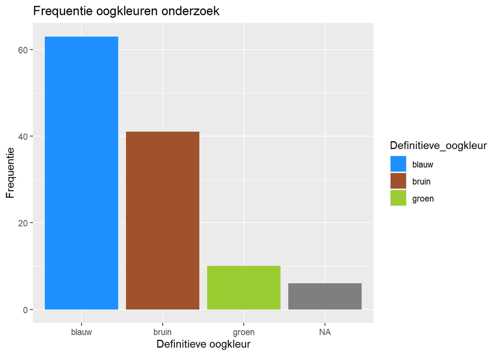

```r
#Plot een histogram om de waarnemingen van de oogkleuren te visualiseren
library(ggplot2)

#Kolom wordt een factor
Oogkleur_simpel$Definitieve_oogkleur <- as.factor(Oogkleur_simpel$Definitieve_oogkleur)

# Maak een plotobject met de dataset
plot_data <- ggplot(data = Oogkleur_simpel, aes(x = Definitieve_oogkleur, fill = Definitieve_oogkleur))

# Histogram met gekleurde balken toevoegen
plot_data <- plot_data + geom_bar()

# Kleuren met scale_fill_manual aanpassen
plot_data <- plot_data + scale_fill_manual(values = c("blauw" = "dodgerblue", "bruin" = "sienna", "groen" = "yellowgreen"))

# Titel en label toevoegen
plot_data <- plot_data +
  labs(x = "Definitieve oogkleur", y = "Frequentie", title = "Frequentie oogkleuren onderzoek")

# Weergeef histogram
print(plot_data)
```

In totaal waren er 120 deelnemers die meededen aan het eigen onderzoek. Hiervan waren er 63 met een blauwe oogkleur, 41 met een bruine oogkleur, 10 met een groene oogkleur en 6 waarbij we de oogkleur niet konden vaststellen.

Omdat de data uit het literatuuronderzoek in percentages is, zijn ook de percentages van de waarnemingen van de oogkleur uit dit onderzoek berekend.

```r
#Percentage van de oogkleuren in de dataset berekenen per oogkleur
# Blauwe oogkleur
# Totaal aantal waarnemingen berekenen
totaal_waarnemingen <- nrow(Oogkleur_simpel)

# Aantal waarnemingen met blauwe oogkleur tellen
aantal_blauw <- sum(Oogkleur_simpel$Definitieve_oogkleur == "blauw", na.rm = TRUE)

# Het percentage blauwe oogkeuren berekenen van de dataset
percentage_blauw <- (aantal_blauw / totaal_waarnemingen) * 100

# Het percentage tonen
cat("Percentage blauwe oogkleur:", percentage_blauw, "%\n")
```

```
## Percentage blauwe oogkleur: 52.5 %
```

```r
# Bruine oogkleur
# Totaal aantal waarnemingen berekenen
totaal_waarnemingen <- nrow(Oogkleur_simpel)

# Aantal waarnemingen met bruine oogkleur tellen
aantal_bruin <- sum(Oogkleur_simpel$Definitieve_oogkleur == "bruin", na.rm = TRUE)

# Het percentage bruine oogkeuren berekenen van de dataset
percentage_bruin <- (aantal_bruin / totaal_waarnemingen) * 100

# Het percentage tonen
cat("Percentage bruine oogkleur:", percentage_bruin, "%\n")
```

```
## Percentage bruine oogkleur: 34.16667 %
```

```r
# Groene oogkleur
# Totaal aantal waarnemingen berekenen
totaal_waarnemingen <- nrow(Oogkleur_simpel)

# Aantal waarnemingen met groen oogkleur tellen
aantal_groen <- sum(Oogkleur_simpel$Definitieve_oogkleur == "groen", na.rm = TRUE)

# Het percentage groene oogkeuren berekenen van de dataset
percentage_groen <- (aantal_groen / totaal_waarnemingen) * 100

# Het percentage tonen
cat("Percentage groene oogkleur:", percentage_groen, "%\n")
```

```
## Percentage groene oogkleur: 8.333333 %
```

Uiteindelijk werd de data uit het literatuuronderzoek en het eigen onderzoek met elkaar vergeleken om te kijken of er verschillen in de waarnemingen zaten.

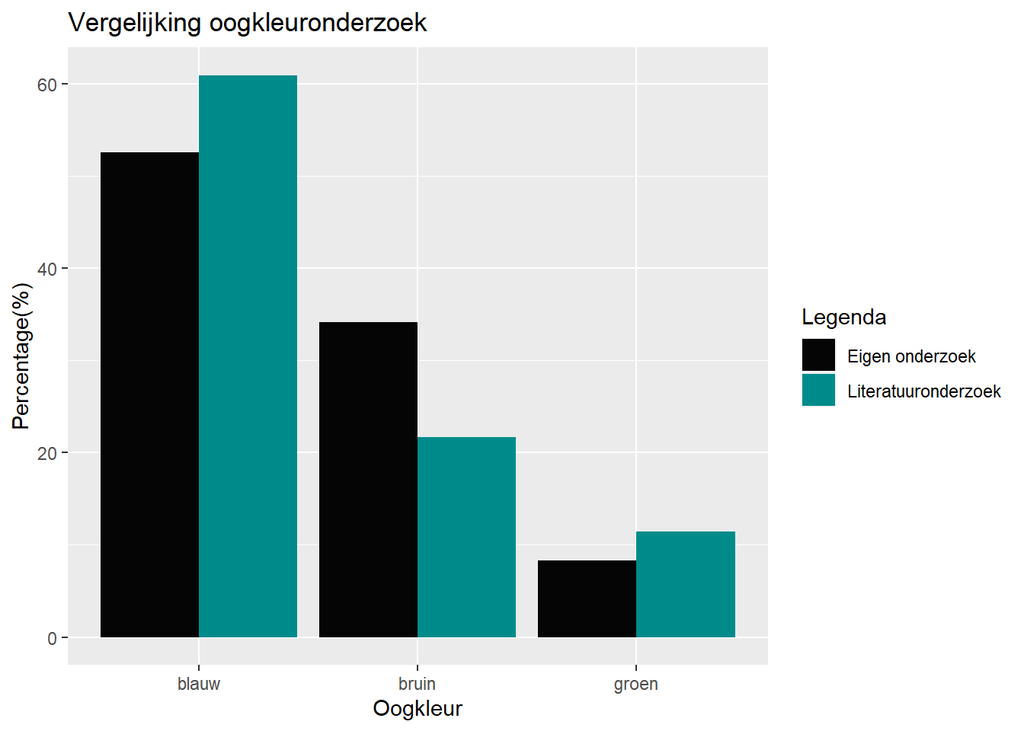

```r
library(ggplot2)
#Data uit literatuuronderzoek en data uit eigen onderzoek vergelijken
#Data literatuuronderzoek
l_percentage_blauw <- 60.90
l_percentage_bruin <- 21.70
l_percentage_groen <- 11.40

# Dataframe maken met data van literatuuronderzoek
literatuuronderzoek <- data.frame(
  Oogkleur = c("blauw", "bruin", "groen"),
  Percentage = c(l_percentage_blauw, l_percentage_bruin, l_percentage_groen),
  Legenda = "Literatuuronderzoek"
)

# Dataframe maken met eigen onderzoek
eigen_onderzoek <- data.frame(
  Oogkleur = c("blauw", "bruin", "groen"),
  Percentage = c(percentage_blauw, percentage_bruin, percentage_groen),
  Legenda = "Eigen onderzoek"
)

# Samenvoegen van beide dataframes
combinatie_data <- rbind(literatuuronderzoek, eigen_onderzoek)

# Plot met data uit beide onderzoeken
plot_data <- ggplot(data = combinatie_data, aes(x = Oogkleur, y = Percentage, fill = Legenda)) +
  geom_bar(stat = "identity", position = "dodge") +
  labs(x = "Oogkleur", y = "Percentage(%)", title = "Vergelijking oogkleuronderzoek") +
  scale_fill_manual(values = c("Literatuuronderzoek" = "cyan4", "Eigen onderzoek" = "grey2"))

# Weergeef plot
print(plot_data)
```